# PPOL670 | Introduction to Data Science

Strings and Text-as-Data

Week 10

# String Manipulations

## Example 1

We’ll use what we know of manipulation to clean the following string.

```r
dirty_string = "22Clean 5674.5this $%&*_@string!"
dirty_string
```

Remove the numbers…

```r
dirty_string = str_remove_all(dirty_string,"\\d")
dirty_string
```

Remove the odd punctuation.

```r
dirty_string = str_remove_all(dirty_string,"[:punct:]")
dirty_string
```

```r
dirty_string = str_remove_all(dirty_string,"\\$")
dirty_string
```

### Example 2

```r
dirty_text <-"

    A comedian with no political experience has won the most votes in the first round of Ukraine's presidential elections, according to exit polls.

They say Volodymyr Zelenskiy - who played the president on TV - received 30.4% of the vote, with current leader Petro Poroshenko second on 17.8%.

The two - who have expressed largely pro-EU opinions - are set to take part in a run-off election next month.


"

dirty_text
```

Remove the excess white space

```r
dirty_text <- str_trim(dirty_text)
dirty_text
```

Remove the spacing in the middle of the text (`\n` = “return”/“new line”)

```r
dirty_text <- str_remove_all(dirty_text,"\\n")
dirty_text
```

Let’s remove the subordinate clauses.

```r
text_list <- str_split(dirty_text," - ")
text_list
```

```r
text_list <- text_list[[1]]
text_list <- text_list[c(-2,-4)]
text_list
```

```r
dirty_text <-  str_c(text_list,collapse = " ")
dirty_text
```

Add spaces between the sentences (but need to make sure we don’t split up the percentages!)

```r
dirty_text <- str_replace_all(dirty_text,"\\.(?!\\d)",". ")
dirty_text
```

# Text as Data: Exploring Inaugural Presidential Speaches

Read data in and clean.

```r
inaug_dat <-
  read_csv("Data/inaug_speeches.csv")
head(inaug_dat)
```

| X1 | Name | Inaugural Address | Date | text |
| --- | --- | --- | --- | --- |
| 4 | George Washington | First Inaugural Address | Thursday, April 30, 1789 | Fellow-Citizens of the Senate and of the House of Representatives: \xa0\xa0AMONG the vicissitudes incident to life no event could have filled me with greater anxieties than that of which the notificat… |
| 5 | George Washington | Second Inaugural Address | Monday, March 4, 1793 | Fellow Citizens: \xa0\xa0I AM again called upon by the voice of my country to execute the functions of its Chief Magistrate. When the occasion proper for it shall arrive, I shall endeavor to express t… |
| 6 | John Adams | Inaugural Address | Saturday, March 4, 1797 | \xa0\xa0WHEN it was first perceived, in early times, that no middle course for America remained between unlimited submission to a foreign legislature and a total independence of its claims, men of ref… |
| 7 | Thomas Jefferson | First Inaugural Address | Wednesday, March 4, 1801 | Friends and Fellow-Citizens: \xa0\xa0CALLED upon to undertake the duties of the first executive office of our country, I avail myself of the presence of that portion of my fellow-citizens which is her… |
| 8 | Thomas Jefferson | Second Inaugural Address | Monday, March 4, 1805 | \xa0\xa0PROCEEDING, fellow-citizens, to that qualification which the Constitution requires before my entrance on the charge again conferred on me, it is my duty to express the deep sense I entertain o… |
| 9 | James Madison | First Inaugural Address | Saturday, March 4, 1809 | \xa0\xa0UNWILLING to depart from examples of the most revered authority, I avail myself of the occasion now presented to express the profound impression made on me by the call of my country to the sta… |

Clean data.

```r
dat <-
  inaug_dat %>%
  transmute(president = str_to_lower(Name) %>% str_replace_all(.," ","_"),
            address = ifelse(str_detect(`Inaugural Address`,"First"),"first","second"),
            date = as.Date(Date,"%A, %B %d, %Y"),
            year = lubridate::year(date),
            length = str_count(text),
            text = text)

# Adjust for one problematic date
dat[dat$president=="bill_clinton" & dat$address=="second",]$date = as.Date("1997-01-20")
dat[dat$president=="bill_clinton" & dat$address=="second",]$year = 1997

head(dat)
```

| president | address | date | year | length | text |
| --- | --- | --- | --- | --- | --- |
| george_washington | first | 1789-04-30 | 1789 | 8641 | Fellow-Citizens of the Senate and of the House of Representatives: \xa0\xa0AMONG the vicissitudes incident to life no event could have filled me with greater anxieties than that of which the notificat… |
| george_washington | second | 1793-03-04 | 1793 | 805 | Fellow Citizens: \xa0\xa0I AM again called upon by the voice of my country to execute the functions of its Chief Magistrate. When the occasion proper for it shall arrive, I shall endeavor to express t… |
| john_adams | second | 1797-03-04 | 1797 | 13914 | \xa0\xa0WHEN it was first perceived, in early times, that no middle course for America remained between unlimited submission to a foreign legislature and a total independence of its claims, men of ref… |
| thomas_jefferson | first | 1801-03-04 | 1801 | 10170 | Friends and Fellow-Citizens: \xa0\xa0CALLED upon to undertake the duties of the first executive office of our country, I avail myself of the presence of that portion of my fellow-citizens which is her… |
| thomas_jefferson | second | 1805-03-04 | 1805 | 12947 | \xa0\xa0PROCEEDING, fellow-citizens, to that qualification which the Constitution requires before my entrance on the charge again conferred on me, it is my duty to express the deep sense I entertain o… |
| james_madison | first | 1809-03-04 | 1809 | 7031 | \xa0\xa0UNWILLING to depart from examples of the most revered authority, I avail myself of the occasion now presented to express the profound impression made on me by the call of my country to the sta… |

Let’s look at the length of speeches over time.

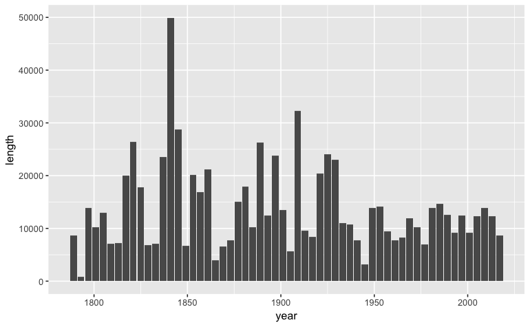

```r
dat %>%
  ggplot(aes(year,length)) +
  geom_col()
```

Who was the most/least verbose?

```r
dat %>%
  filter(max(length)==length) %>%
  select(president,length)
```

| president | length |
| --- | --- |
| william_henry_harrison | 49871 |

```r
dat %>%
  filter(min(length)==length) %>%
  select(president,length)
```

| president | length |
| --- | --- |
| george_washington | 805 |

Convert text to tidy format.

```r
text_dat <-
  dat %>%
  unnest_tokens(word,text)

head(text_dat)
```

| president | address | date | year | length | word |
| --- | --- | --- | --- | --- | --- |
| george_washington | first | 1789-04-30 | 1789 | 8641 | fellow |
| george_washington | first | 1789-04-30 | 1789 | 8641 | citizens |
| george_washington | first | 1789-04-30 | 1789 | 8641 | of |
| george_washington | first | 1789-04-30 | 1789 | 8641 | the |
| george_washington | first | 1789-04-30 | 1789 | 8641 | senate |
| george_washington | first | 1789-04-30 | 1789 | 8641 | and |

Remove stopwords and digits.

```r
text_dat <-
  text_dat %>%
  anti_join(stop_words,by="word") %>%
  filter(!str_detect(word,"\\d")) %>%

  # From the TM package (must install if you don't have)
  mutate(word = tm::removePunctuation(word))


head(text_dat)
```

| president | address | date | year | length | word |
| --- | --- | --- | --- | --- | --- |
| george_washington | first | 1789-04-30 | 1789 | 8641 | fellow |
| george_washington | first | 1789-04-30 | 1789 | 8641 | citizens |
| george_washington | first | 1789-04-30 | 1789 | 8641 | senate |
| george_washington | first | 1789-04-30 | 1789 | 8641 | house |
| george_washington | first | 1789-04-30 | 1789 | 8641 | representatives |
| george_washington | first | 1789-04-30 | 1789 | 8641 | vicissitudes |

Count term frequencies.

```r
text_dat_freq <-
  text_dat %>%
  group_by(president,address,year) %>%
  count(word,sort=T) %>%
  ungroup()
```

Top 25 most common words?

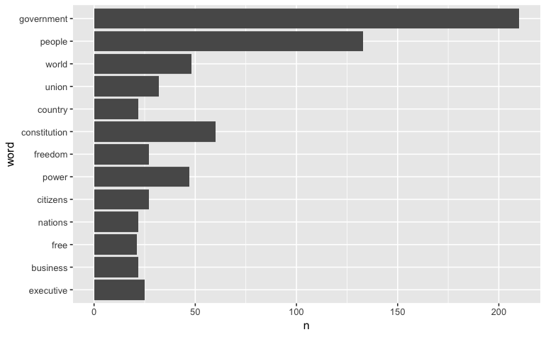

```r
text_dat_freq %>%
  mutate(word = reorder(word,n)) %>%
  slice(1:25) %>%
  ggplot(aes(word,n)) +
  geom_col() +
  coord_flip()
```

Let’s look at the top ten words by president.

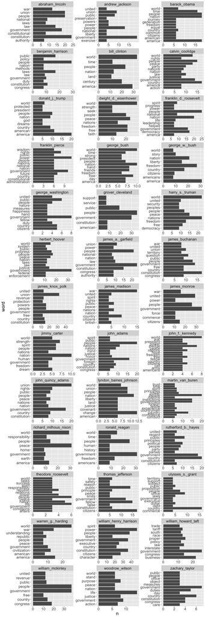

```r
text_dat %>%
  group_by(president) %>%
  top_n(10,n) %>%
  ggplot(aes(word,n)) +
  geom_col() +
  coord_flip() +
  facet_wrap(~president,scales = "free",ncol=3) +
  theme(text = element_text(size=18))
```

## Sentiment

Let’s examine the sentiment of the speeches.

```r
text_dat_sent <-
  text_dat %>%
  inner_join(get_sentiments("afinn"),by='word')

text_dat_sent
```

| president | address | date | year | length | word | score |
| --- | --- | --- | --- | --- | --- | --- |
| george_washington | first | 1789-04-30 | 1789 | 8641 | love | 3 |
| george_washington | first | 1789-04-30 | 1789 | 8641 | retreat | -1 |
| george_washington | first | 1789-04-30 | 1789 | 8641 | hopes | 2 |
| george_washington | first | 1789-04-30 | 1789 | 8641 | retreat | -1 |
| george_washington | first | 1789-04-30 | 1789 | 8641 | dear | 2 |
| george_washington | first | 1789-04-30 | 1789 | 8641 | waste | -1 |
| george_washington | first | 1789-04-30 | 1789 | 8641 | committed | 1 |
| george_washington | first | 1789-04-30 | 1789 | 8641 | trust | 1 |
| george_washington | first | 1789-04-30 | 1789 | 8641 | distrustful | -3 |
| george_washington | first | 1789-04-30 | 1789 | 8641 | inferior | -2 |

[output cut: 990 more lines]

On Average, which president was “most postive”?

```r
text_dat_sent %>%
  group_by(president,year,address) %>%
  summarize(ave_score = mean(score)) %>%
  ungroup %>%
  filter(ave_score == max(ave_score))
```

| president | year | address | ave_score |
| --- | --- | --- | --- |
| george_bush | 1989 | second | 1.198276 |

The most negative?

```r
text_dat_sent %>%
  group_by(president,year,address) %>%
  summarize(ave_score = mean(score)) %>%
  ungroup %>%
  filter(ave_score == min(ave_score))
```

| president | year | address | ave_score |
| --- | --- | --- | --- |
| abraham_lincoln | 1861 | first | -0.1523179 |

Let’s examin the sentiment of the most recent Republican presidents.

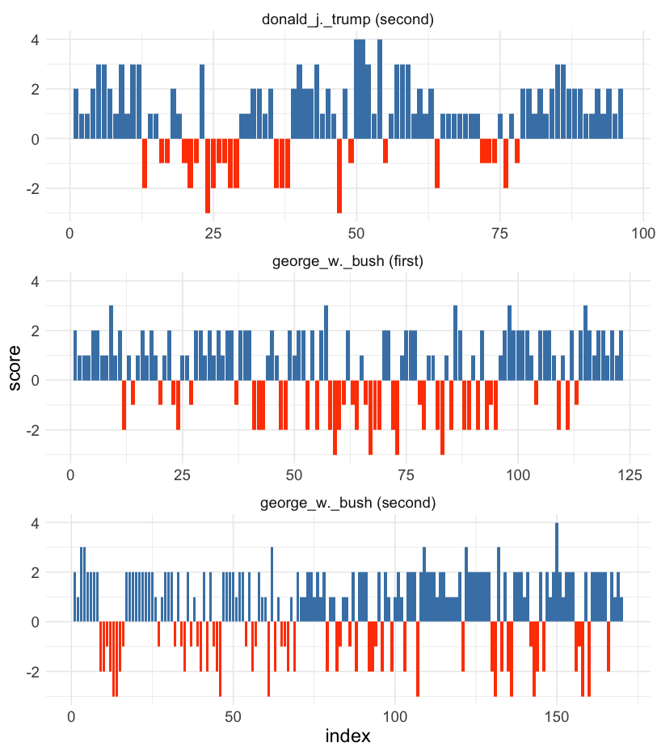

```r
text_dat_sent %>%
  filter(president %in% c("george_w._bush","donald_j._trump")) %>%
  group_by(president,address) %>%
  mutate(index = row_number()) %>%
  ungroup %>%
  mutate(id = str_glue("{president} ({address})"),
         classify = ifelse(score>0,"steelblue","orangered")) %>%

  # Now plot
  ggplot(aes(index,score,fill=classify)) +
  geom_col(show.legend = F) +
  facet_wrap(~id,scales = "free_x",ncol=1) +
  scale_fill_identity() +
  theme_minimal() +
  theme(text = element_text(size=16))
```

Let’s explore a different sentiment classifier and see if we get a similar story. Note that we’ll do *everything* all in one seamless pipeline. Recall that the `bing` sentiment classifier is binary (“positive”/“negative”)

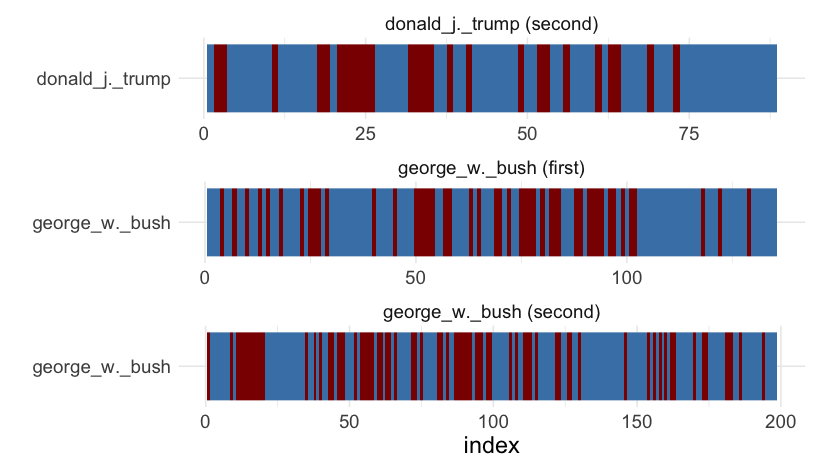

```r
# First Classify
text_dat %>%
  inner_join(get_sentiments("bing"),by='word') %>%


  # Next subset out the relevant presidents
  filter(president %in% c("george_w._bush","donald_j._trump")) %>%
  group_by(president,address) %>%
  mutate(index = row_number()) %>%
  ungroup %>%
  mutate(id = str_glue("{president} ({address})"),
         classify = ifelse(sentiment=="positive","steelblue","darkred")) %>%

  # Now plot
  ggplot(aes(index,president,fill=classify)) +
  geom_tile(show.legend = F) +
  facet_wrap(~id,scales = "free",ncol=1) +
  scale_fill_identity() +
  labs(y="") +
  theme_minimal() +
  theme(text = element_text(size=16))
```

Looks largely the same…

## Topic Models

Let’s subset the text and convert to a document term matrix.

```r
dtm
```

```
<<DocumentTermMatrix (documents: 56, terms: 8611)>>
Non-/sparse entries: 32955/449261
Sparsity           : 93%
Maximal term length: 17
Weighting          : term frequency (tf)
```

```r
inaug_lda <- LDA(dtm,k=2)
```

Let’s explore the topic output.

What are the top ten words most associated with each topic?

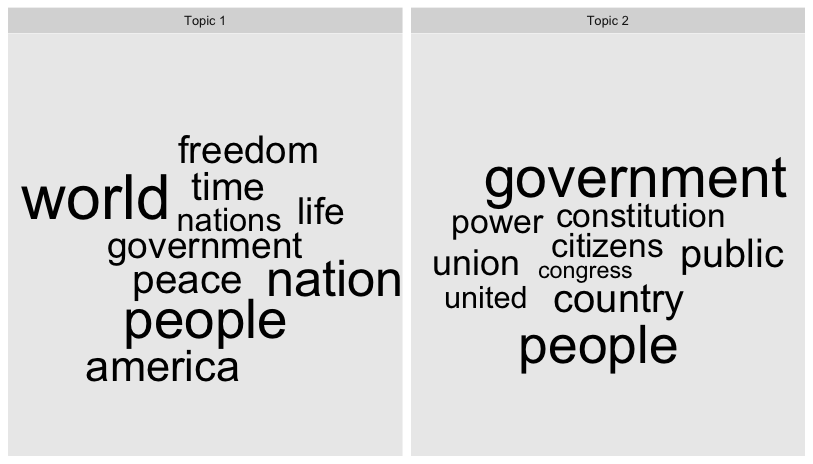

Can we associate meaning to these topics?

Let’s associate presidents speeches to specific topic entries. We can easily reassociate our topic allocations with the words used to find which presidents were most associated with the two topics.

| document | topic | gamma |
| --- | --- | --- |
| abraham_lincoln (first) | 1 | 0.000 |
| abraham_lincoln (second) | 1 | 0.592 |
| andrew_jackson (first) | 1 | 0.000 |
| andrew_jackson (second) | 1 | 0.000 |
| barack_obama (first) | 1 | 1.000 |
| barack_obama (second) | 1 | 1.000 |
| benjamin_harrison (second) | 1 | 0.408 |
| bill_clinton (first) | 1 | 1.000 |
| bill_clinton (second) | 1 | 1.000 |
| calvin_coolidge (second) | 1 | 0.634 |

[output cut: 102 more lines]

Let’s now re-assign the years.

```r
year_key <-
  text_dat %>%
  mutate(document = str_glue("{president} ({address})") %>% as.character) %>%
  select(document,year) %>%
  unique()

year_key
```

| document | year |
| --- | --- |
| george_washington (first) | 1789 |
| george_washington (second) | 1793 |
| john_adams (second) | 1797 |
| thomas_jefferson (first) | 1801 |
| thomas_jefferson (second) | 1805 |
| james_madison (first) | 1809 |
| james_madison (second) | 1813 |
| james_monroe (first) | 1817 |
| james_monroe (second) | 1821 |
| john_quincy_adams (second) | 1825 |

[output cut: 48 more lines]

Merge the two data sources and examine the change in topic membership over time…

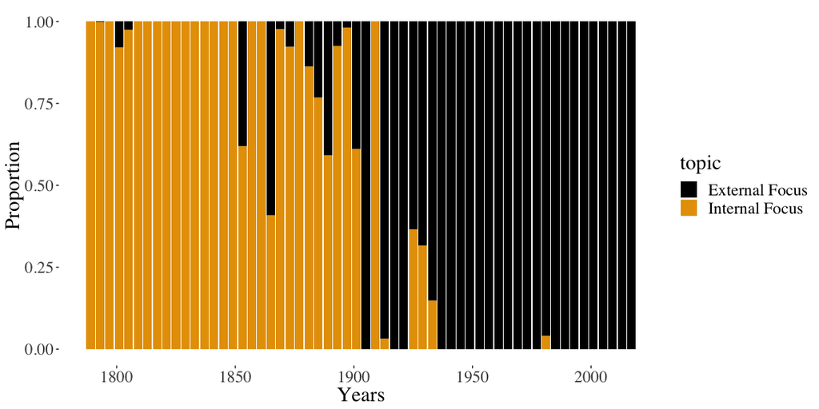

```r
full_join(pres_topic_member,year_key,by = "document") %>%
  mutate(topic = ifelse(topic==1,"External Focus","Internal Focus")) %>%
  ggplot(aes(year,gamma,fill=topic)) +
  geom_col(position="stack") +
  ggthemes::scale_fill_colorblind() +
  ggthemes::theme_tufte() +
  labs(y="Proportion",x="Years") +
  theme(text=element_text(size=20))
```